# PredictionAssignment

Eduard Santamaria

February 18, 2018

## Executive Summary

In this project, the goal is to predict the manner in which an exercise was done using data from accelerometers on the belt, forearm, arm, and dumbbell of 6 participants. They were asked to perform barbell lifts correctly and incorrectly in 5 different ways. More information is available from the website http://web.archive.org/web/20161224072740/http:/groupware.les.inf.puc-rio.br/har (see the section on the Weight Lifting Exercise Dataset).

## Tidying up the data

The dataset contains many empty fields and needs some tidying up before we can proceed with the rest of steps. To clean the data the following operations are performed:

```
# Non-aggregate variables and variables that are not going to be used for prediction:
ignoreList <- c("X", "user_name",    "new_window",           "num_window",
                "cvtd_timestamp",    "raw_timestamp_part_1", "raw_timestamp_part_2")

cleanUpInput <- function(inputDF, ignore = ignoreList, isTest = FALSE) {

  classeValues <- inputDF$classe

  # Remove variables from ignore
  clean1 <- inputDF[, !(names(inputDF) %in% c(ignore, "classe"))]

  # Remove variables with near zero variance
  clean2 <- clean1[,-nearZeroVar(clean1)]

  # Turn factor variables to numeric
  clean3 <- clean2
  for(i in 1:ncol(clean2)) {
    if (class(clean2[,i]) == "factor") {
      clean3[,i] <- as.numeric(as.character(clean2[,i]))
    }
  }

  # Replace missing values
  clean4 <- as.data.frame(impute(clean3))

  # Repeat remove variables with near zero variance
  if (isTest)
    clean5 <- clean4
  else
    clean5 <- clean4[,-nearZeroVar(clean4)]

  return(list(df = clean5, classe = classeValues))
}
```

This function will also be applied to the testing dataset used for the prediction.

## Feature selection

```
processCorMatrix <- function(corMatrix, threshold = 0.75) {
  # Initialize selected and discarded sets
  select <- vector("numeric")
  discard <- vector("numeric")

  n <- nrow(corMatrix)

  # Iterate over all elements in upper-right part of the diagonal
  for (i in 1:(n - 1)) {
    # if var i has not been discarded, add to select
    if (!(i %in% discard)) {
      select <- c(select, i)
    }
    # discard all vars j with correlation factor greater or equal to threshold
    for (j in (i + 1):n) {
      if (is.na(corMatrix[i, j])) {
        print(paste("AFDSGDSFG", i, j))
      }

      if (corMatrix[i, j] >= threshold) {
        discard <- c(discard, j)

      }
    }
  }
  select
}
```

The next script makes use of the previous support functions to tidy up the dataset and perform an initial selection of covariates.

```r
# source support code
source("cleanUpInput.R")
source("processCorMatrix.R")

# ensure results are repeatable
set.seed(123)

# Read data
training <- read.csv("data/pml-training.csv")

# Tidy data
clean <- cleanUpInput(training)

# Use correlation matrix to select variables
correlationMatrix <- cor(clean$df)
selVars <- processCorMatrix(correlationMatrix)
colnames(correlationMatrix)[selVars]
```

```
##  [1] "roll_belt"            "pitch_belt"           "gyros_belt_x"
##  [4] "gyros_belt_y"         "gyros_belt_z"         "accel_belt_x"
##  [7] "accel_belt_z"         "magnet_belt_y"        "roll_arm"
## [10] "pitch_arm"            "yaw_arm"              "total_accel_arm"
## [13] "gyros_arm_x"          "gyros_arm_y"          "gyros_arm_z"
## [16] "accel_arm_x"          "accel_arm_z"          "magnet_arm_y"
## [19] "roll_dumbbell"        "pitch_dumbbell"       "yaw_dumbbell"
## [22] "total_accel_dumbbell" "gyros_dumbbell_x"     "gyros_dumbbell_y"
## [25] "gyros_dumbbell_z"     "magnet_dumbbell_x"    "magnet_dumbbell_z"
## [28] "roll_forearm"         "pitch_forearm"        "yaw_forearm"
## [31] "total_accel_forearm"  "gyros_forearm_x"      "gyros_forearm_y"
## [34] "accel_forearm_x"      "accel_forearm_y"      "accel_forearm_z"
## [37] "magnet_forearm_x"
```

The plots in the next figure display some of the selected variables. As shown later, these are the four most important ones of our final model. We can certainly see that some values stand out from the rest, for instance in the upper right part of *roll_belt* plot or in the lower left part of *pitch_forearm* plot, but identifying the right variables for the model through visual inspection of such plots would be a difficult and tedious process. Therefore I decide to leave the final selection of variables to the Caret package.

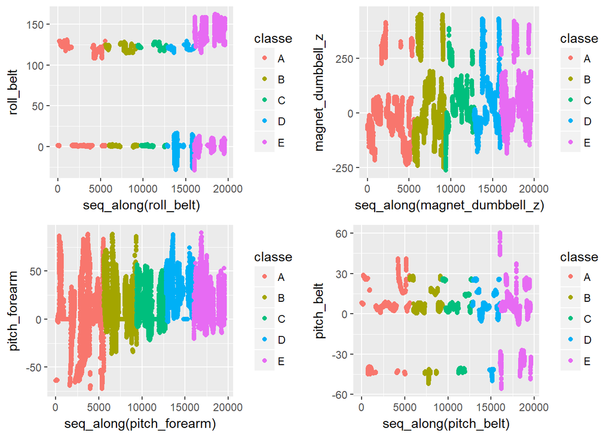

```r
rfDF <- cbind(clean$df[,selVars], 'classe' = clean$classe)

p1 <- qplot(y = roll_belt, data = rfDF) + geom_point(aes(color = classe))
p2 <- qplot(y = magnet_dumbbell_z, data = rfDF) + geom_point(aes(color = classe))
p3 <- qplot(y = pitch_forearm, data = rfDF) + geom_point(aes(color = classe))
p4 <- qplot(y = pitch_belt, data = rfDF) + geom_point(aes(color = classe))

grid.arrange(p1, p2, p3, p4, nrow = 2)
```

## Building the model

Between the handful of training methods presented in the **Practical Machine Learning** course, random forests seem a reasonable option. According to the course material, they have good accuracy, although they may suffer from low training speed, difficult interpretability and overfitting. Speed turns out to be an issue with the problem and the resources at hand. To keep the computing time around ten minutes, only a sample (35%) of the available training data is used for training the model.

```r
inTrain <- createDataPartition(y = clean$classe, p = .35, list = FALSE)
trn <- rfDF[inTrain, ]
tst <- rfDF[-inTrain, ]
```

To create the prediction model I take advantage of the capabilities of the `train()` function. I also use the `trainControl()` function to specify how cross validation will be performed. In the code snippet below, the configuration is defined to perform 10-fold cross-validation.

```r
fitControl <- trainControl(
  method = "cv",
  number = 10)
```

Now we let Caret do the training using random forests with the specified configuration parameters. The features that will be considered are those obtained after evaluating the correlation matrix (see **Feature selection** section above).

```r
modFit <-
  train(classe ~ ., data = trn, method = "rf", trControl = fitControl)
```

Below we see some properties of the resulting model: 6869 samples and 37 predictors were used, and the maximum accuracy reached was 0.98.

```r
modFit
```

```
## Random Forest
##
## 6869 samples
##   37 predictor
##    5 classes: 'A', 'B', 'C', 'D', 'E'
##
## No pre-processing
## Resampling: Cross-Validated (10 fold)
## Summary of sample sizes: 6182, 6183, 6182, 6183, 6182, 6181, ...
## Resampling results across tuning parameters:
##
##   mtry  Accuracy   Kappa
##    2    0.9802010  0.9749474
##   19    0.9788908  0.9732963
##   37    0.9742307  0.9673972
##
## Accuracy was used to select the optimal model using the largest value.
## The final value used for the model was mtry = 2.
```

This is the confusion matrix of the final model:

```r
modFit$finalModel$confusion
```

```
##      A    B    C    D    E class.error
## A 1946    4    1    0    2 0.003584229
## B   24 1290   15    0    0 0.029345372
## C    1   25 1166    6    0 0.026711185
## D    0    0   29 1096    1 0.026642984
## E    0    2   10    4 1247 0.012668250
```

Before predicting with the test data, we can evaluate the model with the remaining values from our previous partitioning. We find out that accuracy is slightly better to the one reached by the model.

```r
pred <- predict(modFit, tst)
cm <- confusionMatrix(pred, tst$classe)

cm$overall[1]
```

```
##  Accuracy
## 0.9822787
```

```r
cm$table
```

```
##           Reference
## Prediction    A    B    C    D    E
##          A 3607   44    6    0    0
##          B   11 2404   33    0    3
##          C    3   20 2173   72    5
##          D    1    0   12 2018   11
##          E    5    0    0    0 2325
```

It is also interesting to have a look at the importance of the involved variables:

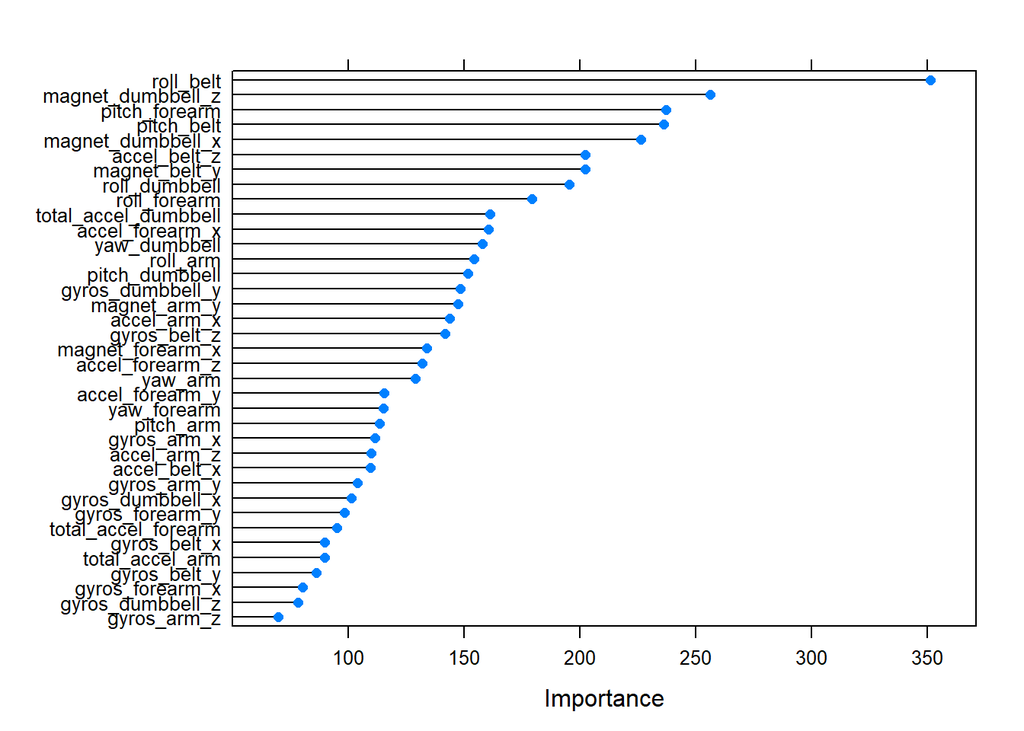

```r
plot(varImp(modFit, scale=FALSE))
```

## Predict with the test data

As the last step, we predict one more time, but using the test data that was reserved for this purpose. The expected accuracy should be close to 0.98, which is the value obtained when the model was evaluated with cross-validation.

```r
testing <- read.csv("data/pml-testing.csv")
clean_t <- cleanUpInput(testing, isTest = TRUE)
predict(modFit, clean_t$df)
```

```
##  [1] B A C A A E D B A A B C B A E E A B B B
## Levels: A B C D E
```

## Conclusion

The main problem encountered while doing the project was understanding the structure of the input data. Rows that seem to contain instant measurements are combined with rows that contain aggregated values, such as averages, minimums or maximums, among other more complex computations. Some columns only make sense for the latter, which means there are lots of empty fields. This was confusing and my inclination was to believe that the relevant rows were the ones with aggregate values, which somehow would summarize and characterize the performance of the participants during one run of the exercise. It wasn’t until I had a look at the test data that I realized that this was not the case.

The second problem was selecting the variables, there are many of them and manual approaches and visual inspection of many plots would not help.

Finally, choosing a training method and its related parameters was not an easy decision either. The **Practical Machine Learning** course of the **Data Science Specialization** covers a lot of material rather superficially. I researched other resources to learn more about the topic, but in the end my decisions were primarily based on trial and error.